# Health Insight Survey dashboard

[interactive chart not shown]

# Home

For queries relating to this dashboard, contact health.studies@ons.gov.uk

**About the Health Insight Survey**

Commissioned by NHS England, the Health Insight Survey (HIS) is designed to give patients the opportunity to offer regular feedback about their experiences of NHS services, including: GP practices, hospital waiting lists, dental care, pharmacies and community health services. Understanding patient experience is important to making sure the NHS can offer the best possible service. The survey asks about experiences of accessing care at a local GP practice and experience of other NHS services in England. It includes questions on a range of topics, such as how easy or difficult it is to contact practices, understanding of how requests are handled, and overall experience of care across NHS services.  
The [statistics produced by the HIS](https://www.ons.gov.uk/peoplepopulationandcommunity/healthandsocialcare/healthcaresystem/datasets/experiencesofnhshealthcareservicesinengland) are official statistics in development. This means they are new official statistics that are undergoing a development and will be tested with users, in line with the standards of trustworthiness, quality and value in the Code of Practice for Statistics.

Question branching in the Health Insight Survey

The Health Insight Survey questionnaire and details on branching can be accessed under the [Survey questionnaire](https://www.ons.gov.uk/surveys/informationforhouseholdsandindividuals/householdandindividualsurveys/healthinsightsurvey/aboutthehealthinsightsurvey#survey-questionnaire) section on our information page. Note, some question numbers may appear multiple times in the branching diagram below. This is because the results for these questions are combined in the outputs that we publish.

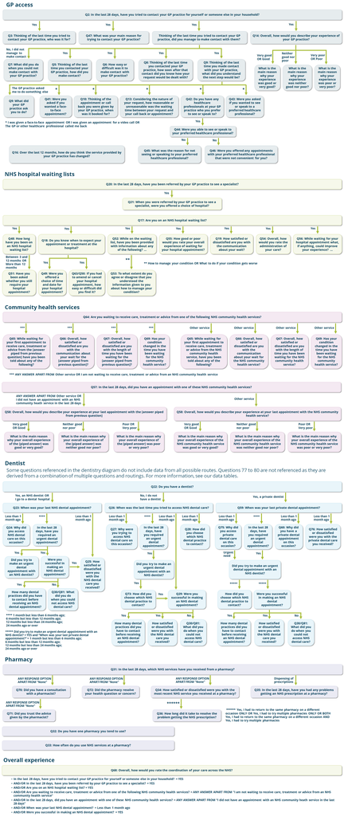

**Further information**

Uncertainty in our estimates

The Health Insight Survey (HIS) uses a sample rather than the population (of England) as a whole, which means there is uncertainty in our statistics. Although the statistics produced as outputs from the survey data are our best estimates, they will not be identical to the unknown true numbers we are trying to measure. We use confidence intervals to measure the uncertainty of our estimates.  
The HIS sample, as with all surveys, is subject to possible bias. For example:  
- Participants need access to an email address to participate  
- Unlike the COVID-19 Infection Survey, no incentives were offered to take part in the HIS  
These factors might affect response rates in some groups more than others. For more information see ”Representativeness” in [Section 5: Quality characteristics of the Health Insight Survey](https://www.ons.gov.uk/peoplepopulationandcommunity/healthandsocialcare/healthcaresystem/methodologies/experiencesofnhshealthcareservicesinenglandqmi#quality-characteristics-of-the-health-insight-survey).

Interpreting change over time in our estimates

Changes over time should be interpreted with caution, particularly as new participants were added to the survey in Waves 14, 17, 21 and 25. Data should be examined over multiple time points to determine if a real trend exists.

The estimates are weighted, but fluctuations can still occur owing to factors such as seasonality, changes in sample composition—especially when new participants are added (as occurred in Waves 14, 17, 21 and 25) —adjustments to weighting methodology and changes in NHS geography (e.g. at the organisational level or because of patients moving between GP practices). Trends may reflect genuine changes in access to NHS healthcare services or be influenced by these factors. Data should be examined over multiple time points to determine if a real trend exists.

Changes to Integrated Care Board footprints

Changes to some Integrated Care Board (ICB) footprints came into effect on 1 April 2026, following a series of mergers and boundary changes. From wave 23 onwards, the ICB estimates in our data have been calculated using these new ICB footprints. Regional charts in the dashboard will display the previous ICBs when filtered up to wave 22, and the new ICBs when filtered from wave 23 onwards.

Number of respondents

The number of respondents by demographic to each question can be viewed by hovering over the bar or confidence interval for any of the response options. It should be noted that the number of respondents displayed is the number of individuals within the demographic group who responded to the overall question. It is not the number within the demographic group who gave a specific response to the question.

Text will appear above charts if at least one demographic group responding to the question had fewer than 100 responses. This is an arbitrarily chosen value to indicate that responses may be low. However, uncertainty owing to lower sample size will also be reflected in confidence intervals.

Confidence intervals

Data from the Health Insight Survey are analysed using a 95% confidence interval. A confidence interval gives an indication of the degree of uncertainty of an estimate and helps to decide how precise a sample estimate is. It specifies a range of values likely to contain the unknown population value. A 95% confidence means that if we drew 20 random samples we would expect that, on average, 19 out of the 20 (95%) resulting confidence intervals would contain the true population value and 1 in 20 (5%) would not.

There is no definition of what constitutes a good or bad confidence interval, only that smaller is generally better. Ultimately, it depends on the purpose of the analysis and how the data are intended to be used.

How is sample bias mitigated in the Health Insight Survey?

We apply weighting to our HIS survey results to ensure they are representative of the target population. This adjusts for differential inclusion or response rates of demographic groups, which could otherwise result in under-representation (for example, of younger age groups). The HIS sample, as with all surveys, may still be subject to possible bias that is not fully addressed by the weighting methodology. The weighting process may be refined or improved in subsequent publications. Details of our weighting are described in [Section 6: Methods used to produce the data](https://www.ons.gov.uk/peoplepopulationandcommunity/healthandsocialcare/healthcaresystem/methodologies/experiencesofnhshealthcareservicesinenglandqmi#methods-used-to-produce-the-data).

What data are available in this dashboard?

Almost all [estimates](https://www.ons.gov.uk/peoplepopulationandcommunity/healthandsocialcare/healthcaresystem/datasets/experiencesofnhshealthcareservicesinengland) from the relevant wave are included in this dashboard. The cross-tabulated results for GPP-047-2, GPP-006-2a, GPP-008-3, GPP-013-2, GPP-015, CHS-065, CHS-066, CHS-067 and CHS-058-3 have not been visualised by demographic breakdown, because there are too many variables to be able to concisely visualise the data. However, these estimates are available in our data tables.

Data will not show for categories within a visualisation if the value has be suppressed because of low sample counts.

From Wave 24 onwards, we will no longer publish results from question GPP-004 - “Thinking of the last time you tried to contact your GP practice, did you manage to make contact with them? This could be in person, on the phone or online.” This is because it is no longer a relevant measure of patient experience, having been designed around traditional routes of access, particularly telephone contact. These routes have changed significantly in recent years, with growing use of digital and online consultations, apps and messaging and the question as it stood is no longer clear, for example whether it refers to when a request is submitted or when a response is received. We will develop new iterations of this question, which better reflect modern general practice.

How to navigate this dashboard

- Choose a topic area: select a topic from the left-hand navigation panel to find survey questions relating to that topic. Please note that it may take a few seconds for each page to fully load.
- Choose a question: at the top of each topic page there is an expandable list of all questions on the page labelled ‘Click here to view list of questions’. You can use this list to help you to navigate the row of question tabs below. Please note that the question tabs are ordered by the occurrence of questions in the survey.
- Select a wave (time period): the Health Insight Survey is analysed in four-weekly time periods called ‘waves’. The ‘select a wave’ filter can be used to filter the question you are viewing, by time period. The data is restricted the most recent 13 waves to mitigate slow loading times, but will allow for comparisons between the latest wave and the most relevant wave one year previously. Please note that changes over time should be interpreted with caution, as outlined in the ‘Interpreting change over time in our estimates’ section above.
- Navigate by demographic breakdown: the second row of tabs can be used to navigate the question you have selected by demographic breakdown. For each chart in the dashboard, ‘All’ refers to the overall result for England.

Study periods in the Health Insight Survey

Responses for the Health Insight Survey are collected every 4 weeks, during a 22 day response window or Wave, as shown in the table below.

| Wave number | Response window |
| --- | --- |
| 27 | 21 July 2026 to 12 August 2026 |
| 26 | 23 June 2026 to 15 July 2026 |
| 25 | 26 May 2026 to 17 June 2026 |
| 24 | 28 April 2026 to 20 May 2026 |
| 23 | 31 March 2026 to 22 April 2026 |
| 22 | 03 March 2026 to 25 March 2026 |
| 21 | 03 February 2026 to 25 February 2026 |
| 20 | 06 January 2026 to 28 January 2026 |
| 19 | 09 December 2025 to 31 December 2025 |
| 18 | 11 November 2025 to 03 December 2025 |
| 17 | 14 October 2025 to 05 November 2025 |
| 16 | 16 September 2025 to 08 October 2025 |
| 15 | 19 August 2025 to 10 September 2025 |

**Notes for our estimates**

- The Health Insight Survey includes people living in England aged 16 years and over.
- Age is based on the participant’s age at the start of the Health Insight Survey.
- Weighted percentages ensure that the sample reflects the larger population accurately. These have been adjusted for differential response rates of demographic groups, which could otherwise cause under-representation in the sample. The counts are unweighted.
- The lower and upper 95% confidence limits have been provided. These form a confidence interval, which is a measure of the statistical precision of an estimate and shows the range of uncertainty around the estimated figure. Calculations based on small numbers of events are often subject to random fluctuations. As a general rule, if the confidence interval around one figure overlaps with the interval around another, we cannot say with certainty that there is more than a chance difference between the two figures.
- Respondents are assigned to an Integrated Care Board (ICB) and Region by linking them to their GP practice through the Personal Demographic Service (PDS), and then to the associated Primary Care Network. A small number of participants could not be linked to the PDS and therefore could not be assigned to an ICB or Region. Consequently, the total number of responses for the Region and ICB breakdowns is lower than the total number of responses for a given question.
- Findings in the survey are based on self-reported responses from individuals, and the estimates, in particular those estimating the number of people using the different types of NHS services [GPP-002, GPP-047, GPP-020, GPP-017, DEN-022, PCY-031], may differ from administrative data sources used to collect activity data.
- Integrated Care Board data are omitted from questions DEN-027, DEN-028, DEN-029 and DEN-030 due to low counts.
- Participants are removed from the denominator only if they have died or moved out of England. For further information about how the response rates are calculated see our Health Insight Study Quality and Methodology Information report.
- Calibration totals are averaged mid-year population projections for 2024 and 2025.
- For CHS-058-3, respondents who had more than one community health service appointment in the last 28 days were asked to describe their overall experience for their most recent appointment.
- Some of the questions in the Health Insight Survey have multiple response options (e.g., ‘Very easy’, ‘Easy’, ‘Neither easy nor difficult’, ‘Difficult’, ‘Very difficult’). To help users view the result of a question more quickly and easily, we have grouped some responses. This is usually an aggregation of two individual responses (e.g., Easy = ‘Very easy’ and ‘Easy’).
- Our estimates utilise the NHS regions. These regions differ slightly from other Office for National Statistics publications.

**Respondent characteristics**

Ensuring a representative sample of the general population is important for producing survey-based estimates broken down by characteristics such as age, sex, and NHS region. Aspects of the Health Insight Survey (HIS) study design might affect how representative the study population is in comparison with the wider population.

We apply weighting to our HIS survey results to ensure they are representative of the target population. This weighting adjusts for differential inclusion or response rates of demographic groups, which could otherwise result in under-representation (for example, of younger age groups).

Use the tabs below to explore the representation of characteristics within our sample.

[interactive chart not shown]

**Sex**

Representation of respondents by sex

**Age group**

Representation of respondents by age group

**Ethnic group**

Representation of respondents by ethnic group

**IMD**

Representation of respondents by index of multiple deprivation

**Long-term health**

Representation of respondents by long-term health condition

**Rural/urban**

Representation of respondents by rural/urban classification

**Region**

**NHS regions**

Representation of respondents by NHS Region

**NE & Yorks**

Representation of respondents by Integrated Care Board (North East and Yorkshire)

**North West**

Representation of respondents by Integrated Care Board (North West)

**East**

Representation of respondents by Integrated Care Board (East of England)

Changes to some Integrated Care Board (ICB) footprints came into effect in April 2026. Data in this chart will display the new ICB areas when filtered from wave 23 onwards.

**Midlands**

Representation of respondents by Integrated Care Board (Midlands)

**London**

Representation of respondents by Integrated Care Board (London)

Changes to some Integrated Care Board (ICB) footprints came into effect in April 2026. Data in this chart will display the new ICB areas when filtered from wave 23 onwards.

**South East**

Representation of respondents by Integrated Care Board (South East)

Changes to some Integrated Care Board (ICB) footprints came into effect in April 2026. Data in this chart will display the new ICB areas when filtered from wave 23 onwards.

**South West**

Representation of respondents by Integrated Care Board (South West)

**ICB map**

Map showing the number of respondents by Integrated Care Board (ICB)

This map shows data for the latest wave (27 - responses between 21 July 2026 to 12 August 2026). It does not interact with the wave selection filter.

[interactive chart not shown]

**Corrections**

This section contains information on corrections made to the Health Insight Survey, which impact this dashboard. Our data sets, corrections and previous versions of the data can be found on the [Experiences of NHS healthcare services in England](https://www.ons.gov.uk/peoplepopulationandcommunity/healthandsocialcare/healthcaresystem/datasets/experiencesofnhshealthcareservicesinengland) data page.

- For Wave 19, we have corrected errors in the response data (Tables 1 and 10) and in the estimates for all questions (Tables 2-9), with the exception of the ‘Region’ and ‘Integrated Care Board’ estimates in these tables (which remain unchanged). A small number of survey responses (357) were previously excluded in error. The response data and the estimates have been revised to include responses from these participants.